# Regular Expression

==> The regular expressions can be defined as the sequence of characters which are used to search for a pattern in a string.

```python
import re
```

### Regex Functions

[figure not shown]

### findall()

==> This method returns a list containing a list of all matches of a pattern within the string.

==> It returns the patterns in the order they are found.

==> If there are no matches, then an empty list is returned.

```python
import re
```

```python
str = "how are you. how is everything"
```

```python
matches = re.findall("How", str,flags=re.IGNORECASE)
print(matches)
```

```
['how', 'how']
```

### match

==> The match object contains the information about the search and the output.

==> If there is no match found, the None object is returned.

```python
str = "How are you. How is everything"
```

```python
matches = re.search("How", str)
```

```python
print(type(matches))

print(matches) #matches is the search object
```

```
<class 're.Match'>
<re.Match object; span=(0, 3), match='How'>
```

#### Match Object Methods

==> **span()** : It returns the tuple containing the starting and end position of the match.

==> **string()** : It returns a string passed into the function.

==> **group()** : The part of the string is returned where the match is found.

```python
str = "How are you. How is everything"
```

```python
matches = re.search("How", str)

print(matches.span())

print(matches.group())

print(matches.string)
```

```
(0, 3)
How
How are you. How is everything
```

### Forming a regular expression

==> A regular expression can be formed by using the mix of **meta-characters, special sequences**, and **sets**.

#### Meta-Characters

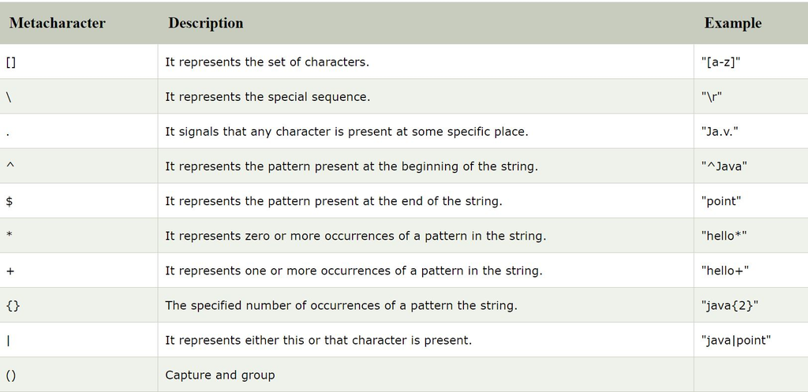

#### Special Sequences

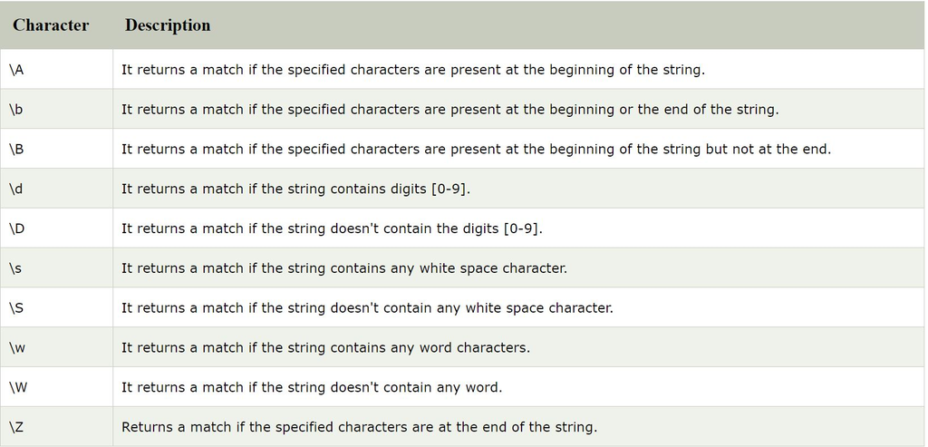

#### Sets

==> A set is a group of characters given inside a pair of square brackets. It represents the special meaning.

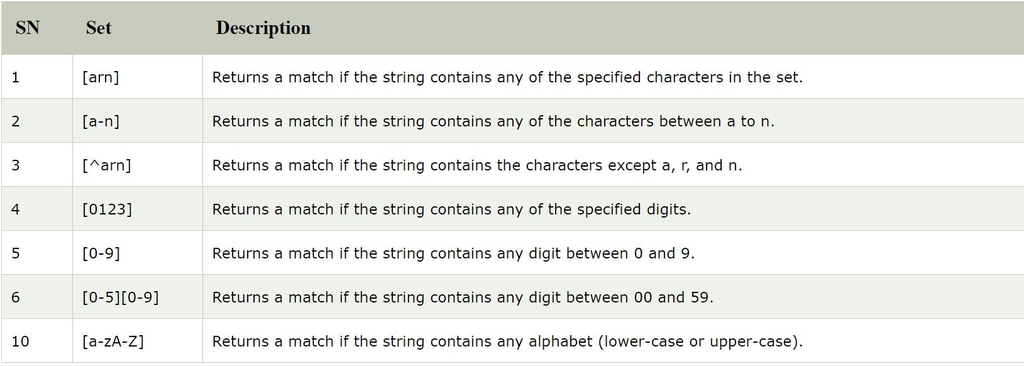

### Compile()

==> Regular expressions are compiled into pattern objects, which have methods for various operations such as searching for pattern matches or performing string substitutions.

```python
# compile() creates regular expression character class [a-e],
# which is equivalent to [abcde].
# class [abcde] will match with string with 'a', 'b', 'c', 'd', 'e'.
p = re.compile('[a-e]')
```

```python
# findall() searches for the Regular Expression and return a list upon finding
print(p.findall("Hello this is A Marvell Universe"))
```

```
['e', 'a', 'e', 'e', 'e']
```

==> **Metacharacter** blackslash **‘\’** has a very important role as it signals various sequences.

==> If the blackslash is to be used without its special meaning as metacharcter, use **’\’**.

```python
# \d   Matches any decimal digit, this is equivalent
#      to the set class [0-9].
# \D   Matches any non-digit character.
# \s   Matches any whitespace character.
# \S   Matches any non-whitespace character
# \w   Matches any alphanumeric character, this is
#      equivalent to the class [a-zA-Z0-9_].
# \W   Matches any non-alphanumeric character.
```

```python
# \d is equivalent to [0-9].
p = re.compile('\d')
print(p.findall("I went to him at 11 A.M. on 4th July 1886"))
```

```
['1', '1', '4', '1', '8', '8', '6']
```

```python
# \d+ will match a group on [0-9], group of one or greater size
p = re.compile('\d+')
print(p.findall("I went to him at 11 A.M. on 4th July 1886"))
```

```
['11', '4', '1886']
```

```python
# \w is equivalent to [a-zA-Z0-9_].
p = re.compile('\w')
print(p.findall("He said * in some_lang."))
```

```
['H', 'e', 's', 'a', 'i', 'd', 'i', 'n', 's', 'o', 'm', 'e', '_', 'l', 'a', 'n', 'g']
```

```python
# \w+ matches to group of alphanumeric charcter.
p = re.compile('\w+')
print(p.findall("I went to him at 11 A.M., he said *** in some_language."))
```

```
['I', 'went', 'to', 'him', 'at', '11', 'A', 'M', 'he', 'said', 'in', 'some_language']
```

```python
# \W matches to non alphanumeric characters.
p = re.compile('\W')
print(p.findall("he said *** in some_language."))
```

```
[' ', ' ', '*', '*', '*', ' ', ' ', '.']
```

### Split()

==> Split string by the occurrences of a character or a pattern, upon finding that pattern, the remaining characters from the string are returned as part of the resulting list.

##### Syntax : re.split(pattern, string, maxsplit=0, flags=0)

```python
from re import split
```

```python
s = "How are you, how the things going on!"
```

```python
print(re.split('\W+','How',maxsplit=1))
```

```
['How']
```

```python
ss = 'Words,  words,Words'
```

```python
print(split('\W',ss))
```

```
['Words', '', '', 'words', 'Words']
```

```python
# '\W+' denotes Non-Alphanumeric Characters or group of characters
# Upon finding ',' or whitespace ' ', the split(), splits the string from that point
print(split('\W+', 'Words, words , Words'))
print(split('\W+', "Word's words Words"))
```

```
['Words', 'words', 'Words']
['Word', 's', 'words', 'Words']
```

```python
# Here ':', ' ' ,',' are not AlphaNumeric thus, the point where splitting occurs
print(split('\W+', 'On 12th Jan 2016, at 11:02 AM'))
```

```
['On', '12th', 'Jan', '2016', 'at', '11', '02', 'AM']
```

```python
# '\d+' denotes Numeric Characters or group of characters
# Spliting occurs at '12', '2016', '11', '02' only
print(split('\d+', 'On 12th Jan 2016, at 11:02 AM'))
```

```
['On ', 'th Jan ', ', at ', ':', ' AM']
```

```python
# Splitting will occurs only once, at '12', returned list will have length 2
print(re.split('\d+', 'On 12th Jan 2016, at 11:02 AM', 1))
```

```
['On ', 'th Jan 2016, at 11:02 AM']
```

```python
# 'Boy' and 'boy' will be treated same when flags = re.IGNORECASE
print(re.split('[a-f]+', 'Aey, Boy oh boy, come here', flags = re.IGNORECASE))
print(re.split('[a-f]+', 'Aey, Boy oh boy, come here'))
```

```
['', 'y, ', 'oy oh ', 'oy, ', 'om', ' h', 'r', '']
['A', 'y, Boy oh ', 'oy, ', 'om', ' h', 'r', '']
```

```python
print(re.split('[a-z]+', 'Aey, Boy oh boy, come here',1,flags=re.IGNORECASE))
```

```
['', ', Boy oh boy, come here']
```

### sub()

##### Syntax : re.sub(pattern, repl, string, count=0, flags=0)

==> The ‘sub’ in the function stands for SubString, a certain regular expression pattern is searched in the given string(3rd parameter), and upon finding the substring pattern is replaced by repl(2nd parameter), count checks and maintains the number of times this occurs.

```python
# Regular Expression pattern 'ub' matches the string at "Subject" and "Uber".
# As the CASE has been ignored, using Flag, 'ub' should match twice with the string
# Upon matching, 'ub' is replaced by '~*' in "Subject", and in "Uber", 'Ub' is replaced.
print(re.sub('ub', '~*' , 'Subject has Uber booked already', flags = re.IGNORECASE))
```

```
S~*ject has ~*er booked already
```

```python
# Consider the Case Senstivity, 'Ub' in "Uber", will not be reaplced.
print(re.sub('ub', '~*' , 'Subject has Uber booked already'))
```

```
S~*ject has Uber booked already
```

```python
# As count has been given value 1, the maximum times replacement occurs is 1
print(re.sub('ub', '~*' , 'Subject has Uber booked already', count=1, flags = re.IGNORECASE))
```

```
S~*ject has Uber booked already
```

```python
print(re.sub(r'AND', ' & ', 'Baked Beans And Spam', flags=re.IGNORECASE))
```

```
Baked Beans  &  Spam
```

```python
# 'r' before the patter denotes RE, \s is for start and end of a String.
print(re.sub(r'\sAND\s', ' & ', 'Baked Beans And Spam', flags=re.IGNORECASE))
```

```
Baked Beans & Spam
```

### subn()

##### Syntax : re.subn(pattern, repl, string, count=0, flags=0)

==> **subn()** is similar to **sub()** in all ways, except in its way to providing output.

==> It returns a tuple with count of total of replacement and the new string rather than just the string.

```python
print(re.subn('ub', '~*' , 'Subject has Uber booked already'))
t = re.subn('ub', '~*' , 'Subject has Uber booked already', flags = re.IGNORECASE)
print(t)
print(len(t))
```

```
('S~*ject has Uber booked already', 1)
('S~*ject has ~*er booked already', 2)
2
```

```python
# This will give same output as sub() would have
print(t[0])
print(t[1])
```

```
S~*ject has ~*er booked already
2
```

### escape()

##### Syntax : re.escape(string)

==> Return string with all non-alphanumerics backslashed, this is useful if you want to match an arbitrary literal string that may have regular expression metacharacters in it.

```python
# escape() returns a string with BackSlash '\', before every Non-Alphanumeric Character
# In 1st case only ' ', is not alphanumeric
print(re.escape("This is Awseome even 1 AM"))
```

```
This\ is\ Awseome\ even\ 1\ AM
```

```python
# In 2nd case, ' ', caret '^', '-', '[]', '\' are not alphanumeric
print(re.escape("I Asked what is this [a-9], he said \t ^WoW"))
```

```
I\ Asked\ what\ is\ this\ \[a\-9\],\ he\ said\ \	\ \^WoW
```

### Search()

==> This method either returns None (if the pattern doesn’t match), or a re.MatchObject that contains information about the matching part of the string.

==> This method stops after the first match, so this is best suited for testing a regular expression more than extracting data.

```python
# Lets use a regular expression to match a date string
# in the form of Month name followed by day number
regex = r"([a-zA-Z]+) (\d+)"

match = re.search(regex, "I was born on Dec 27")

if match != None:

    # We reach here when the expression "([a-zA-Z]+) (\d+)"
    # matches the date string.

    # This will print [14, 20), since it matches at index 14
    # and ends at 20.
    print ("Match at index %s, %s" % (match.start(), match.end()))

    # We us group() method to get all the matches and
    # captured groups. The groups contain the matched values.
    # In particular:
    #    match.group(0) always returns the fully matched string
    #    match.group(1) match.group(2), ... return the capture
    #    groups in order from left to right in the input string
    #    match.group() is equivalent to match.group(0)

    # So this will print "June 24"
    print ("Full match: %s" % (match.group(0)))

    # So this will print "June"
    print ("Month: %s" % (match.group(1)))

    # So this will print "24"
    print ("Day: %s" % (match.group(2)))

else:
    print ("The regex pattern does not match.")
```

```
Match at index 14, 20
Full match: Dec 27
Month: Dec
Day: 27
```

### findall()

==> Return all non-overlapping matches of pattern in string, as a list of strings.

==> The string is scanned left-to-right, and matches are returned in the order found.

```python
# A sample text string where regular expression
# is searched.
string = """Hello my Number is 7600299260 and
        my friend's number is 7041645834"""

# A sample regular expression to find digits.
regex = '\d+'

match = re.findall(regex, string)
print(match)

# This example is contributed by Ayush Saluja.
```

```
['7600299260', '7041645834']
```

##### Extract Email

```python
s = 'Hello from rajzalavadia50@gmail.com to raj.zalavadia@greylabs.com about the meeting @2PM'

# \S matches any non-whitespace character
# @ for as in the Email
# + for Repeats a character one or more times
lst = re.findall('\S+@\S+', s)

print(lst)
```

```
['rajzalavadia50@gmail.com', 'raj.zalavadia@greylabs.com']
```

### RAJKUMAR ZALAVADIA - Mo: 7041645834 Email : rajzalavadia50@gmail.com